# Data visualization using python modified

- Batch - B
- Group Number - 5
- Task 2.1 Product Analysis
- Group Member Name - Thathireddy Vishnuvardhan Reddy

```python
import pandas as pd
import numpy as np
import matplotlib.pyplot as plt
import seaborn as sns
import warnings
warnings.simplefilter(action = 'ignore')
%pip install seaborn
```

```python
df=pd.read_csv("Store.csv",encoding='latin')
```

```python
df.head(5)
```

|  | ï»¿Row ID | Order ID | Order Date | Ship Date | Ship Mode | Customer ID | Customer Name | Segment | Country | City_Code | State_Code | Postal Code | Product ID | Category | Sub-Category | Product Name | Sales | Quantity | Discount | Profit |
| --- | --- | --- | --- | --- | --- | --- | --- | --- | --- | --- | --- | --- | --- | --- | --- | --- | --- | --- | --- | --- |
| 0 | 1 | CA-2013-152156 | 11/9/2013 | 11/12/2013 | Second Class | CG-12520 | Claire Gute | Consumer | United States | C259 | S16 | 42420 | FUR-BO-10001798 | Furniture | Bookcases | Bush Somerset Collection Bookcase | 261.9600 | 2 | 0.00 | 41.9136 |
| 1 | 2 | CA-2013-152156 | 11/9/2013 | 11/12/2013 | Second Class | CG-12520 | Claire Gute | Consumer | United States | C259 | S16 | 42420 | FUR-CH-10000454 | Furniture | Chairs | Hon Deluxe Fabric Upholstered Stacking Chairs,... | 731.9400 | 3 | 0.00 | 219.5820 |
| 2 | 3 | CA-2013-138688 | 6/13/2013 | 6/17/2013 | Second Class | DV-13045 | Darrin Van Huff | Corporate | United States | C64 | S04 | 90036 | OFF-LA-10000240 | Office Supplies | Labels | Self-Adhesive Address Labels for Typewriters b... | 14.6200 | 2 | 0.00 | 6.8714 |
| 3 | 4 | US-2012-108966 | 10/11/2012 | 10/18/2012 | Standard Class | SO-20335 | Sean O'Donnell | Consumer | United States | C150 | S09 | 33311 | FUR-TA-10000577 | Furniture | Tables | Bretford CR4500 Series Slim Rectangular Table | 957.5775 | 5 | 0.45 | -383.0310 |
| 4 | 5 | US-2012-108966 | 10/11/2012 | 10/18/2012 | Standard Class | SO-20335 | Sean O'Donnell | Consumer | United States | C150 | S09 | 33311 | OFF-ST-10000760 | Office Supplies | Storage | Eldon Fold 'N Roll Cart System | 22.3680 | 2 | 0.20 | 2.5164 |

# Different types of product categories

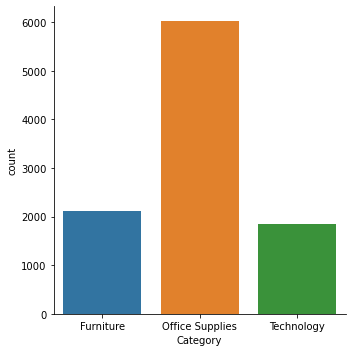

```python
sns.catplot(x='Category',kind='count',data=df)
```

Insights:The Office Supplies is on top with the most number of categories,When we see the count of each Category we see the diierence of each Category.

# Various sub-categories of products

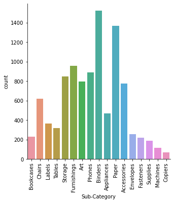

```python
sns.catplot(x='Sub-Category',kind='count',data=df)
plt.xticks(rotation=90)
plt.show()
```

Insights:The Blinders nd paper is on top of sub-category,When we see the count of each , we see that difference and highest count of the each sub-category.

# Product with highest demand in each segment

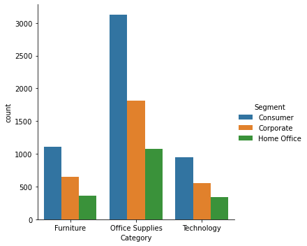

```python
sns.catplot(x='Category',kind='count',hue='Segment',data=df)
plt.show()
```

The Consumer Segemnt has highest demand in each category,when we count the category shows the difference in each segment and shwoing highest demand in each segment

```python
df[['Sub-Category','Sales']].max()
```

```
Sub-Category      Tables
Sales           22638.48
dtype: object
```

```python
df[['Segment','Profit']].max()
```

[output not shown]

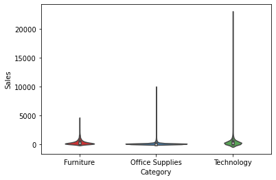

```python
sns.violinplot(df['Category'],df['Sales'],palette="Set1")
```

Insights:The category has highest sales in technology product ,plot will show the which category got sold highest nd how much sales got on other product as well.

```python
df['Segment'].value_counts()
```

```
Consumer       5188
Corporate      3016
Home Office    1781
Name: Segment, dtype: int64
```

insights:count the values in segment by value_counts and its also showing which segement has highest count.

```python
df[['Category','Segment']].max()
```

[output not shown]

```python
df4=pd.read_excel(r"C:\Users\vthathireddy\Documents\Capstone Project5_Time Series\Capstone7_Time Series\Region_Master.xlsx")
```

```python
df4.head()
```

|  | Region_ID | Region_Name |
| --- | --- | --- |
| 0 | R1 | North |
| 1 | R2 | South |
| 2 | R3 | East |
| 3 | R4 | West |
| 4 | R5 | Central |

```python
df5=pd.read_excel(r"C:\Users\vthathireddy\Documents\Capstone Project5_Time Series\Capstone7_Time Series\Region_State_Mapping.xlsx")
```

```python
df5.head()
```

|  | State_Code | Region_ID |
| --- | --- | --- |
| 0 | S01 | R2 |
| 1 | S02 | R4 |
| 2 | S03 | R2 |
| 3 | S04 | R4 |
| 4 | S05 | R4 |

```python
data1=pd.merge(df,df5,how='left')
```

```python
data1.head()
```

|  | ï»¿Row ID | Order ID | Order Date | Ship Date | Ship Mode | Customer ID | Customer Name | Segment | Country | City_Code | ... | Postal Code | Product ID | Category | Sub-Category | Product Name | Sales | Quantity | Discount | Profit | Region_ID |
| --- | --- | --- | --- | --- | --- | --- | --- | --- | --- | --- | --- | --- | --- | --- | --- | --- | --- | --- | --- | --- | --- |
| 0 | 1 | CA-2013-152156 | 11/9/2013 | 11/12/2013 | Second Class | CG-12520 | Claire Gute | Consumer | United States | C259 | ... | 42420 | FUR-BO-10001798 | Furniture | Bookcases | Bush Somerset Collection Bookcase | 261.9600 | 2 | 0.00 | 41.9136 | R2 |
| 1 | 2 | CA-2013-152156 | 11/9/2013 | 11/12/2013 | Second Class | CG-12520 | Claire Gute | Consumer | United States | C259 | ... | 42420 | FUR-CH-10000454 | Furniture | Chairs | Hon Deluxe Fabric Upholstered Stacking Chairs,... | 731.9400 | 3 | 0.00 | 219.5820 | R2 |
| 2 | 3 | CA-2013-138688 | 6/13/2013 | 6/17/2013 | Second Class | DV-13045 | Darrin Van Huff | Corporate | United States | C64 | ... | 90036 | OFF-LA-10000240 | Office Supplies | Labels | Self-Adhesive Address Labels for Typewriters b... | 14.6200 | 2 | 0.00 | 6.8714 | R4 |
| 3 | 4 | US-2012-108966 | 10/11/2012 | 10/18/2012 | Standard Class | SO-20335 | Sean O'Donnell | Consumer | United States | C150 | ... | 33311 | FUR-TA-10000577 | Furniture | Tables | Bretford CR4500 Series Slim Rectangular Table | 957.5775 | 5 | 0.45 | -383.0310 | R2 |
| 4 | 5 | US-2012-108966 | 10/11/2012 | 10/18/2012 | Standard Class | SO-20335 | Sean O'Donnell | Consumer | United States | C150 | ... | 33311 | OFF-ST-10000760 | Office Supplies | Storage | Eldon Fold 'N Roll Cart System | 22.3680 | 2 | 0.20 | 2.5164 | R2 |

5 rows × 21 columns

```python
data2=pd.merge(data1,df4,how='left')
```

```python
data2.tail()
```

|  | ï»¿Row ID | Order ID | Order Date | Ship Date | Ship Mode | Customer ID | Customer Name | Segment | Country | City_Code | ... | Product ID | Category | Sub-Category | Product Name | Sales | Quantity | Discount | Profit | Region_ID | Region_Name |
| --- | --- | --- | --- | --- | --- | --- | --- | --- | --- | --- | --- | --- | --- | --- | --- | --- | --- | --- | --- | --- | --- |
| 9989 | 9990 | CA-2011-110422 | 1/22/2011 | 1/24/2011 | Second Class | TB-21400 | Tom Boeckenhauer | Consumer | United States | C160 | ... | FUR-FU-10001889 | Furniture | Furnishings | Ultra Door Pull Handle | 25.248 | 3 | 0.2 | 4.1028 | R2 | South |
| 9990 | 9991 | CA-2014-121258 | 2/27/2014 | 3/4/2014 | Standard Class | DB-13060 | Dave Brooks | Consumer | United States | C43 | ... | FUR-FU-10000747 | Furniture | Furnishings | Tenex B1-RE Series Chair Mats for Low Pile Car... | 91.960 | 2 | 0.0 | 15.6332 | R4 | West |
| 9991 | 9992 | CA-2014-121258 | 2/27/2014 | 3/4/2014 | Standard Class | DB-13060 | Dave Brooks | Consumer | United States | C43 | ... | TEC-PH-10003645 | Technology | Phones | Aastra 57i VoIP phone | 258.576 | 2 | 0.2 | 19.3932 | R4 | West |
| 9992 | 9993 | CA-2014-121258 | 2/27/2014 | 3/4/2014 | Standard Class | DB-13060 | Dave Brooks | Consumer | United States | C43 | ... | OFF-PA-10004041 | Office Supplies | Paper | It's Hot Message Books with Stickers, 2 3/4" x 5" | 29.600 | 4 | 0.0 | 13.3200 | R4 | West |
| 9993 | 9994 | CA-2014-119914 | 5/5/2014 | 5/10/2014 | Second Class | CC-12220 | Chris Cortes | Consumer | United States | C108 | ... | OFF-AP-10002684 | Office Supplies | Appliances | Acco 7-Outlet Masterpiece Power Center, Wihtou... | 243.160 | 2 | 0.0 | 72.9480 | R4 | West |

5 rows × 22 columns

```python
data2[['Category','Region_Name']].max()
```

```
Category       Technology
Region_Name          West
dtype: object
```

# Category of the product with highest demand in each region

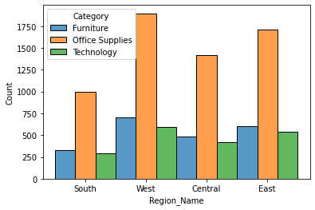

```python
sns.histplot(x='Region_Name',hue='Category',data=data2,multiple='dodge')
```

insights:The west region has highest demand in office supplies.This will shows the other region as well which category has highest demand .

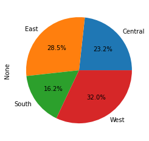

```python
data2.groupby('Region_Name').size().plot(kind='pie',autopct='%.1f%%')
```

# The category of the product which is being sold with highest discounts

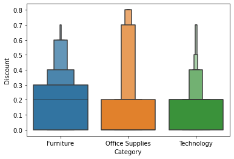

```python
sns.boxenplot(x=df['Category'],y=df['Discount'])
```

Insights:The office supplies has got highest discount in category ,we find that boxenplot and also find other category dsicount.

```python
df6=pd.read_excel(r"C:\Users\vthathireddy\Documents\Capstone Project5_Time Series\Capstone7_Time Series\City_Master.xlsx")
```

```python
df6.head()
```

|  | City_Code | State_Code | City_Name | City_Code.1 |
| --- | --- | --- | --- | --- |
| 0 | C01 | S01 | Auburn | C01 |
| 1 | C02 | S01 | Decatur | C02 |
| 2 | C03 | S01 | Florence | C03 |
| 3 | C04 | S01 | Hoover | C04 |
| 4 | C05 | S01 | Huntsville | C05 |

```python
data3=pd.merge(data2,df6 ,how='left')
```

```python
data3.head()
```

|  | ï»¿Row ID | Order ID | Order Date | Ship Date | Ship Mode | Customer ID | Customer Name | Segment | Country | City_Code | ... | Sub-Category | Product Name | Sales | Quantity | Discount | Profit | Region_ID | Region_Name | City_Name | City_Code.1 |
| --- | --- | --- | --- | --- | --- | --- | --- | --- | --- | --- | --- | --- | --- | --- | --- | --- | --- | --- | --- | --- | --- |
| 0 | 1 | CA-2013-152156 | 11/9/2013 | 11/12/2013 | Second Class | CG-12520 | Claire Gute | Consumer | United States | C259 | ... | Bookcases | Bush Somerset Collection Bookcase | 261.9600 | 2 | 0.00 | 41.9136 | R2 | South | Henderson | C259 |
| 1 | 2 | CA-2013-152156 | 11/9/2013 | 11/12/2013 | Second Class | CG-12520 | Claire Gute | Consumer | United States | C259 | ... | Chairs | Hon Deluxe Fabric Upholstered Stacking Chairs,... | 731.9400 | 3 | 0.00 | 219.5820 | R2 | South | Henderson | C259 |
| 2 | 3 | CA-2013-138688 | 6/13/2013 | 6/17/2013 | Second Class | DV-13045 | Darrin Van Huff | Corporate | United States | C64 | ... | Labels | Self-Adhesive Address Labels for Typewriters b... | 14.6200 | 2 | 0.00 | 6.8714 | R4 | West | Los Angeles | C64 |
| 3 | 4 | US-2012-108966 | 10/11/2012 | 10/18/2012 | Standard Class | SO-20335 | Sean O'Donnell | Consumer | United States | C150 | ... | Tables | Bretford CR4500 Series Slim Rectangular Table | 957.5775 | 5 | 0.45 | -383.0310 | R2 | South | Fort Lauderdale | C150 |
| 4 | 5 | US-2012-108966 | 10/11/2012 | 10/18/2012 | Standard Class | SO-20335 | Sean O'Donnell | Consumer | United States | C150 | ... | Storage | Eldon Fold 'N Roll Cart System | 22.3680 | 2 | 0.20 | 2.5164 | R2 | South | Fort Lauderdale | C150 |

5 rows × 24 columns

# The category of the product that earns highest profit

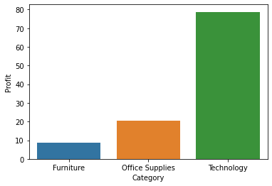

```python
sns.barplot(x='Category',y='Profit',data=df,ci=None)
```

Insights:The technology has got highest profit we find that using barplot and also shows the furniture nd office supplies profit.Furniture got the least profit in Category.